# Worksheet 1

2024-04-08

## R Markdown

In this worksheet we will look at some brain data from some bats found in the Americas. The binomial names of each species are listed, alongside the family classifications. Some diet data are also included, indicating to which dietary guild each bat belongs: insects eater, fruit eater. Alongside brain size, which is depicted as a volume, there is also two other brain regions that were of evolutionary interest to the researchers: neocortex volume and olfactory bulb volume. The neocortex is a portion of the mammalian cerebral cortex involved in higher-order brain functions such as sensory perception, cognition, generation of motor commands, and spatial reasoning. The olfactory bulb is a region of the brain devoted to processing signals from the nose to identify certain scents in the air.

This worksheet asks you to produced some plots, identify trends in the data, and list some measures of central tendency.

This is the answer key. This key will demonstrate how I approached some of the questions, and show the exact scripts I used to build my plots or tables.

The following questions can be completed using either R or Excel.

TASK 1

Open or import the brain volume data. Produce a histogram of the brain_size variable for the full data set, then produce a further two histograms with separate histograms for the fruit and insect feeding bats independently.

```r
library(formatR)
knitr::opts_chunk$set(tidy.opts = list(width.cutoff = 60), tidy = TRUE)
```

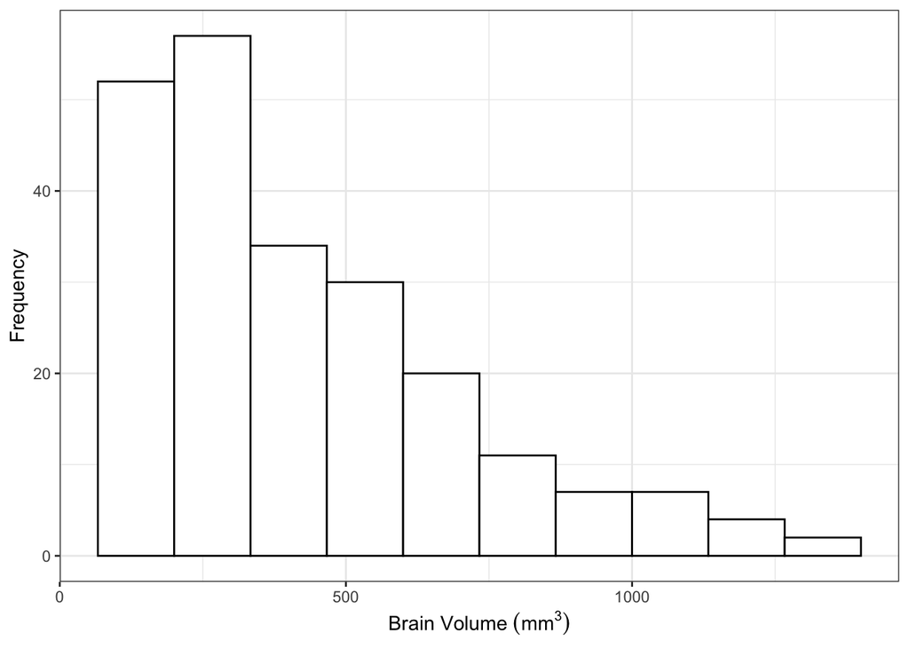

```r
library(plyr)
library(ggplot2)
library(cowplot)
setwd("~/Library/CloudStorage/OneDrive-DePaulUniversity/DePaul/Teaching/2024SQ/Conith/GitHub/BIO206_BIOSTATS/Worksheet_1")
BatBrain <- read.csv("batbrains1.csv")

ggplot(BatBrain, aes(x = brain_size)) + geom_histogram(position = "identity",
    bins = 10, color = "black", fill = "white") + theme_bw() +
    xlab(bquote(`Brain Volume `(mm^3))) + ylab("Frequency")
```

You will find my combined data histogram above. Below you will find a pair of histograms where I have separated the data out based on their diets.

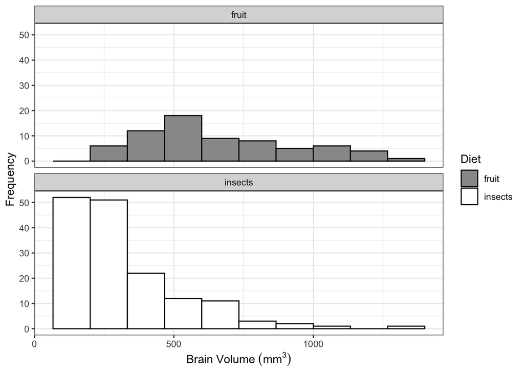

```r
ggplot(BatBrain, aes(x = brain_size, color = Diet)) + geom_histogram(aes(fill = Diet),
    alpha = 1, position = "identity", bins = 10) + scale_fill_manual(values = c("#999999",
    "white")) + scale_color_manual(values = c("black", "black")) +
    theme_bw() + xlab(bquote(`Brain Volume `(mm^3))) + ylab("Frequency") +
    facet_wrap(~Diet, nrow = 2)
```

Task 2

Examine all the plots you just produced. Do you see evidence of skew produced in your combined diet histograms and when the diets have become separated? Do you think one dietary category is driving the trends over the other category, or do they appear similar?

Task 3

```r
## Mean
aggregate(x = cbind(brain_size, neocortex, olfactory_bulb) ~
    Diet, FUN = "mean", data = BatBrain)
```

```
##      Diet brain_size neocortex olfactory_bulb
## 1   fruit   660.5261 188.37101      30.514493
## 2 insects   320.4335  72.06581       7.132903
```

```r
## Median
aggregate(x = cbind(brain_size, neocortex, olfactory_bulb) ~
    Diet, FUN = "median", data = BatBrain)
```

```
##      Diet brain_size neocortex olfactory_bulb
## 1   fruit      584.0     161.4           27.5
## 2 insects      247.2      49.5            5.0
```

Task 4

What do you notice about the mean and median values for all your continuous traits? Are they similar? And, if not, are the means typically greater or smaller than the medians? What does this tell us about the distribution of our data?

I add an example of how the mean and median are different, plotting the mean as the red line and the median as the blue line on the histograms.

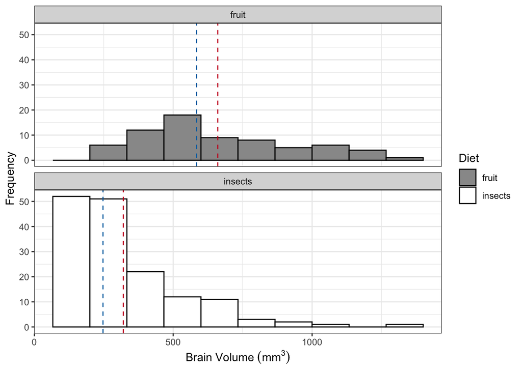

```r
mu <- ddply(BatBrain, "Diet", summarise, grp.mean = mean(brain_size))
me <- ddply(BatBrain, "Diet", summarise, grp.mean = median(brain_size))

ggplot(BatBrain, aes(x = brain_size, color = Diet)) + geom_histogram(aes(fill = Diet),
    alpha = 1, position = "identity", bins = 10) + geom_vline(data = mu,
    aes(xintercept = grp.mean), color = "#ca0020", linetype = "dashed") +
    geom_vline(data = me, aes(xintercept = grp.mean), color = "#0571b0",
        linetype = "dashed") + scale_fill_manual(values = c("#999999",
    "white")) + scale_color_manual(values = c("black", "black")) +
    theme_bw() + xlab(bquote(`Brain Volume `(mm^3))) + ylab("Frequency") +
    facet_wrap(~Diet, nrow = 2)
```

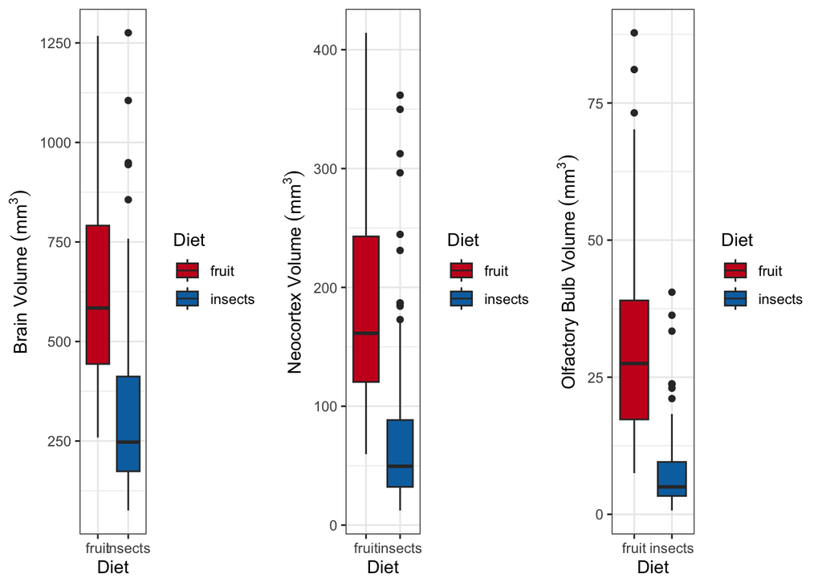

```r
A <- ggplot(BatBrain, aes(x = Diet, y = brain_size, fill = Diet)) +
    geom_boxplot() + scale_fill_manual(values = c("#ca0020",
    "#0571b0")) + theme_bw() + ylab(bquote(`Brain Volume `(mm^3)))

B <- ggplot(BatBrain, aes(x = Diet, y = neocortex, fill = Diet)) +
    geom_boxplot() + scale_fill_manual(values = c("#ca0020",
    "#0571b0")) + theme_bw() + ylab(bquote(`Neocortex Volume `(mm^3)))

C <- ggplot(BatBrain, aes(x = Diet, y = olfactory_bulb, fill = Diet)) +
    geom_boxplot() + scale_fill_manual(values = c("#ca0020",
    "#0571b0")) + theme_bw() + ylab(bquote(`Olfactory Bulb Volume `(mm^3)))

plot_grid(A, B, C, nrow = 1)
```